# Classification

**Course:** HUDK 4050, Week 6

**Author:** Zhichun Liu

**Assignment:** ICE4

**Objectives:**

At the end of this ICE, you will be able to:

1. implement a binary logistic regression model to train a classifier
2. implement a decision tree model to train a classifier
3. implement a Naive Bayes model to train a classifier
4. report model performance on a validation dataset

Classification is among the most important areas of machine learning, and there are a lot of implementations. By the end of this ICE, you’ll have learned about classification in general and the basics of logistic regression, decision tree, and Naive Bayes in particular, as well as their implementation in Python.

## Machine Learning and Classification

### Demystify the buzzword *machine learning*

Think of Pavlov’s dogs. When he would ring a bell, they started to salivate. Pavlov taught them this pattern: every time the bell rings, food is on the way. The dogs soon learned the pattern and eventually began to respond to the bell *before* the food appeared. To cognitive psychologists, human brains are also natural pattern matchers. Since birth, we are constantly trying to find patterns in what we perceive, then associate new patterns with existing patterns in our memory. This pattern-matching process happens automatically. Through our everyday experiences, brains are constantly collecting new patterns and adding them to memory. These patterns then influence the inferences and decisions we make in the future. Inspired by an understanding of how the human brain works, researchers in the field of ML draw on connection to psychology, neuroscience, and the learning sciences.

As discussed in class, one important theoretical root of machine learning is the British mathematitican Alan Turing's work. He envisioned a machine that could, based on an initial set of instructions, modify its own operating instructions over time. The new instructions created by the machine were the result of responses to recently added information. He likened the process to students who have learned basic information from their teachers and went on to develop new knowledge on their own.

> In such a case one would have to admit that the progress of the machine had not been foreseen when its original instructions were put in. It would be like a pupil who had learnt much from his master but had added much more by his own work. (Turing, 1947, p. 13)

Turing’s idea was too theoretical and abstract to implement in 1947, but today’s development of ML is largely inspired by his vision.

Tom Mitchell (1997) wrote a widely-quoted definition of ML:

> “A computer program is said to learn from experience E with respect to some class of tasks T and performance measure P if its performance at tasks in T, as measured by P, improves with experience E” (p. 2).

Therefore, we are essentially "training" a computer program with experiences (often referred as "training data") on a specific task, so that the program will "learn" to "replicate" this experience in similar tasks.

## Classification

In the machine learning world, sometimes "teachers" need to prepare the training experiences for the computer program : We need to clearly tell the computer program what is "right" and what is "wrong" (and yes, sometimes we don't need to do that). This approach is generally referred as *supervised learning*. Classification is an area of supervised machine learning that tries to predict which class or category some entity belongs to, based on its features.

Similar to how one studies for a test by completing endless practice problems, the algorithm “learns” how to properly identify or classify a given input by processing large, labeled datasets until it can do so with an elevated level of confidence—the larger the training set, containing rich and diverse examples, the more accurate the algorithm.

Depending on outcome, we can have *binary classificaiton*, where the predicted variable is a dichotomous, and *multiclass* or *multinomial classificaition*, where the variable can be a categorical variable containing multiple levels.

## Logistic Regression

Logistic regression is probably the most fundamental classification method. As suggested by its name, it belongs to the regression family and is related to the linear regression we have seen. Logistic regression is fast and relatively uncomplicated, and it’s convenient for you to interpret the results.

I will skip the fundementals of logistics regression because it can make this document very long. Here are a couple of videos that you can use to refresh your memory.

- [StatQuest: Logistics Regression](https://youtu.be/yIYKR4sgzI8) This is a very short quick intro.
- [StatQuest: Logistic Regression Details Pt1: Coefficients](https://youtu.be/vN5cNN2-HWE): From this video, you are getting into more details about logistic regression.
- [StatQuest: Logistic Regression Details Pt 2: Maximum Likelihood](https://youtu.be/BfKanl1aSG0): Logistic regression uses a different way of estimating parameters called maximum likelihood (MLE) instead of the simple ordinal least sqaure (OLS) that we have seen in linear regression.
- [Machine Learning by Andrew Ng — Logistic Regression | Classification](https://youtu.be/-la3q9d7AKQ): Here is another intro video from a more machine learning perspective by Andrew Ng. This belongs to his machine learning MOOC course on coursera. He has more videos on logistic regression and classification but you may need to understand a bit of linear algebra to make sense of everything.

Ok, talk is cheap, let's bring up the code!

In this ICE, we will use `ICE4_data.csv`, a simulated dataset of students' MOOC participation.

```python
import pandas as pd
import matplotlib.pyplot as plt
```

In this dataset, we have four variables:

- `certified`: whether the student earned the certificate at the end of the MOOC
- `forum.posts`: how many posts the student has made throughout the course
- `grade`:
- `assignment`: how many optional assignments the student has complemented.

```python
mooc = pd.read_csv("ICE4_Data.csv")
mooc
```

|  | certified | forum.posts | grade | assignment |
| --- | --- | --- | --- | --- |
| 0 | no | 7 | 3 | 9 |
| 1 | no | 7 | 4 | 1 |
| 2 | yes | 191 | 8 | 19 |
| 3 | yes | 130 | 10 | 18 |
| 4 | yes | 135 | 8 | 18 |
| ... | ... | ... | ... | ... |
| 995 | yes | 88 | 10 | 13 |
| 996 | yes | 153 | 10 | 19 |
| 997 | no | 41 | 4 | 3 |
| 998 | no | 47 | 6 | 12 |
| 999 | yes | 112 | 8 | 19 |

1000 rows × 4 columns

Some descriptive data will help us understand the data better.

```python
mooc['certified'].value_counts()
```

```
yes    725
no     275
Name: certified, dtype: int64
```

```python
mooc.describe()
```

|  | forum.posts | grade | assignment |
| --- | --- | --- | --- |
| count | 1000.000000 | 1000.00000 | 1000.000000 |
| mean | 113.107000 | 7.76500 | 13.693000 |
| std | 55.126477 | 2.38232 | 5.011973 |
| min | 1.000000 | 1.00000 | 1.000000 |
| 25% | 72.750000 | 8.00000 | 12.000000 |
| 50% | 118.500000 | 8.00000 | 15.000000 |
| 75% | 160.000000 | 9.00000 | 17.000000 |
| max | 200.000000 | 10.00000 | 20.000000 |

Here instead of using the simple `pd.plotting.scatter_matrix()`, I use the `seaborn` package to plot a prettier graphic. You can tell the `pairplot()` function to use `certified` variable as the color code. Read more here: https://seaborn.pydata.org/generated/seaborn.pairplot.html

```python
import seaborn as sns
```

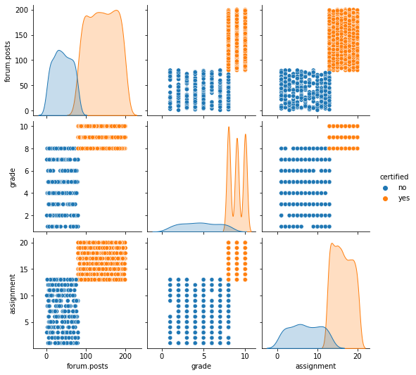

```python
sns.pairplot(mooc, hue = "certified")
```

Before we start to build the logistic regression model, pause one sec, what do you see here from the above descriptives?

```python
## INSERT YOUR COMMENT HERE: ##
```

To build the logistic regression model, we are going to import the `LogisticRegression` from the `sklearn.linear_model`.

```python
from sklearn.linear_model import LogisticRegression
```

But before building the logistic regression model, we still need to prepare the dataset a little bit. First step is to create a dummy variable for `certified`. We are going to use the `pd.get_dummies()` functions.

```python
dummy = pd.get_dummies(mooc['certified'], prefix = 'certified') # Here prefix = 'certified' will create new column names
dummy
```

|  | certified_no | certified_yes |
| --- | --- | --- |
| 0 | 1 | 0 |
| 1 | 1 | 0 |
| 2 | 0 | 1 |
| 3 | 0 | 1 |
| 4 | 0 | 1 |
| ... | ... | ... |
| 995 | 0 | 1 |
| 996 | 0 | 1 |
| 997 | 1 | 0 |
| 998 | 1 | 0 |
| 999 | 0 | 1 |

1000 rows × 2 columns

We really just need one column, so let's do a merge first and then drop the `certified` as it is no longer needed:

```python
moocD = pd.concat([mooc, dummy], axis=1)
moocD = moocD.drop(['certified', 'certified_no'], axis=1)
moocD
```

|  | forum.posts | grade | assignment | certified_yes |
| --- | --- | --- | --- | --- |
| 0 | 7 | 3 | 9 | 0 |
| 1 | 7 | 4 | 1 | 0 |
| 2 | 191 | 8 | 19 | 1 |
| 3 | 130 | 10 | 18 | 1 |
| 4 | 135 | 8 | 18 | 1 |
| ... | ... | ... | ... | ... |
| 995 | 88 | 10 | 13 | 1 |
| 996 | 153 | 10 | 19 | 1 |
| 997 | 41 | 4 | 3 | 0 |
| 998 | 47 | 6 | 12 | 0 |
| 999 | 112 | 8 | 19 | 1 |

1000 rows × 4 columns

Or here is a even quick way, very useful to create one-hot encoding for categorical varaibles

```python
#mooc_dummies = pd.get_dummies(mooc, prefix='certified_recode', columns=['certified'])
#mooc_dummies
```

Our logistic regression model is:

$$ln\frac{p}{1-p} = \beta_0 + \beta_1forum.posts + \beta_2grade + \beta_3assignment$$

where *p* is the probability of earning the certificate. So we need to create an array of Xs, and an arrary for the training labels -- `certified_yes`

```python
Xs = moocD[["forum.posts", "grade", "assignment"]].to_numpy()
certified = moocD.loc[:,"certified_yes"].values.reshape(-1, 1)
```

Then loading `LogisticRegression()` and calling for `LogisticRegression.fit()` is very similar to what we have done in the previous ICE.

```python
moocLogitModel1 = LogisticRegression()
moocLogitModel1.fit(Xs, certified)
```

```
LogisticRegression()
```

We can call for the intercept and coefficients of each parameter and we will have our logistic regression model.

```python
moocLogitModel1.intercept_
```

```
array([-63.13291439])
```

```python
moocLogitModel1.coef_
```

```
array([[0.62419697, 0.52270711, 0.85766257]])
```

If you want to see a nicer output, `statsmodels.api` proides an `sm` model, which does pretty much the same thing:

```python
import statsmodels.api as sm

moocLogitModel2 = sm.Logit(certified, Xs)
moocLogitModel2Fit = moocLogitModel2.fit()
print(moocLogitModel2Fit.summary())
```

```
Optimization terminated successfully.
         Current function value: 22.457768
         Iterations 7
                           Logit Regression Results
==============================================================================
Dep. Variable:                      y   No. Observations:                 1000
Model:                          Logit   Df Residuals:                      997
Method:                           MLE   Df Model:                            2
Date:                Wed, 13 Oct 2021   Pseudo R-squ.:                     inf
Time:                        21:11:11   Log-Likelihood:                -22458.
converged:                       True   LL-Null:                        0.0000
Covariance Type:            nonrobust   LLR p-value:                     1.000
==============================================================================
                 coef    std err          z      P>|z|      [0.025      0.975]
------------------------------------------------------------------------------
x1             0.0378      0.003     10.852      0.000       0.031       0.045
x2            -0.3202      0.047     -6.879      0.000      -0.411      -0.229
x3             0.0315      0.025      1.258      0.208      -0.018       0.081
==============================================================================
```

You probably have noticed that the results of two models are not identical. And you are absolutely correct. `sklearn` and `statsmodels` set the default logistic regression a little bit differently. The most obvious one is `statsmodels` does not estimate the intercept by default. Therefore, the results of all coefficient will be shifted. There are more differences such as the *regularization* parameter. See a discussion here on StackExchange: https://stats.stackexchange.com/questions/203740/logistic-regression-scikit-learn-vs-statsmodels

And here are the `LogisticRegression` [documentation](https://scikit-learn.org/stable/modules/generated/sklearn.linear_model.LogisticRegression.html) in `sklearn` and the `Logit` [documentation](https://www.statsmodels.org/stable/generated/statsmodels.discrete.discrete_model.Logit.html) in `statsmodles`. You may also want to read in detail if you are curious about what is happening under the hood.

But, does it matter if we get different results? Well... yes and no.

First, if your goal is to evaluate the impact of each predictor on the predicted variable, then yes. The implementation in both `sklearn` and `statsmodels` deviate a little bit from the most standard way of logistic regression. So if you want to interpret the result like what you would do in a stats course, then you probably want to spend some time to get into the weeds.

However, if you goal is simply building a classifier, any of these two implementation will do. Both models (i.e., `moocLogitModel1` and `moocLogitModel2`) will be able to predict the `certified_yes` with given features with no problems. We will check their performance at a later time.

## Decision Tree

Let's move on to decision tree. A Decision Tree is another supervised Machine learning algorithm. The decision tree is like a tree with nodes. The branches depend on a number of factors. It splits data into branches like these till it achieves a threshold value. A decision tree consists of the root nodes, children nodes, and leaf nodes.

The simplistic way of understanding decision tree would be a flow chart like this:

[figure not shown]

This is a simple decision tree with a lot of branches but only one possible classfication outcome -- *don't worry*.

Here is another simple decision tree example:

[figure not shown]

Decision trees learn from data to approximate the training data with a set of if-then-else decision rules. The deeper the tree, the more complex the decision rules and the fitter the model.

Decision tree has various algorithms to implement. In `sklearn`, an optimised version of [CART](https://en.wikipedia.org/wiki/Predictive_analytics#Classification_and_regression_trees_.28CART.29) algorithm is used.

Learn more about decision tree:

- [StatsQuest: Decision Trees](https://youtu.be/7VeUPuFGJHk)
- [Normalized Nerd: Decision Tree Classification Clearly Explained!](https://youtu.be/ZVR2Way4nwQ)

Ok, let's get it started!

First, we need to import the `DecisionTreeClassifier` from `sklearn.tree` and then prepare the data.

```python
from sklearn.tree import DecisionTreeClassifier

Xs_tree = mooc.drop('certified', axis = 1)
certified = mooc['certified']
```

And similarly, initialize the classification tree model and then use the Xs and Y to train the model. Only two lines of code.

```python
moocTreeModel = DecisionTreeClassifier()
moocTreeModel.fit(Xs_tree, certified)
```

```
DecisionTreeClassifier()
```

Once we have the model, we have different ways to see what do we get. First, the text representation can be useful when working on applications whitout user interface or when we want to log information about the model into the text file. You can check details about `export_text` in the sklearn [documentation](https://scikit-learn.org/stable/modules/generated/sklearn.tree.export_text.html#sklearn.tree.export_text).

```python
from sklearn import tree
text_representation = tree.export_text(moocTreeModel)
print(text_representation)
```

```
|--- feature_0 <= 79.50
|   |--- class: no
|--- feature_0 >  79.50
|   |--- feature_1 <= 7.50
|   |   |--- class: no
|   |--- feature_1 >  7.50
|   |   |--- class: yes
```

Or try a prettier way with `plot_tree`. This requires `matplotlib`. Make sure it is already loaded. It allows us to easily produce figure of the tree. The more information about `plot_tree` arguments are in the [docs](https://scikit-learn.org/stable/modules/generated/sklearn.tree.plot_tree.html).

[output not shown]

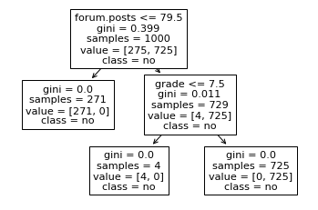

```python
tree.plot_tree(moocTreeModel,
              feature_names = ["forum.posts", "grade", "assignment"], # This is optional. Just let the plot know the features name.
                class_names = mooc.certified # This is also optional. Read more information in the documentation.
              )
```

## Naive Bayes

Naive Bayes models are a group of extremely fast and simple classification algorithms that are often suitable for very high-dimensional datasets. Because they are so fast and have so few tunable parameters, they end up being very useful as a quick-and-dirty baseline for a classification problem.

Naive Bayes classifiers are built on Bayesian classification methods. These rely on Bayes's theorem, which is an equation describing the relationship of conditional probabilities of statistical quantities. In Bayesian classification, we're interested in finding the probability of a label given some observed features, which we can write as $P(L | features)$. Bayes's theorem tells us how to express this in terms of quantities we can compute more directly:

$$P(L | features) = \frac{P(features | L)P(L)}{P(features)}$$

If we are trying to decide between two labels—let's call them L1 and L2—then one way to make this decision is to compute the ratio of the posterior probabilities for each label:

$$\frac{P(L_1 | features)}{P(L_2 | features)} = \frac{P(features | L_1)P(L_1)}{P(features | L_2)P(L_2)}$$

All we need now is some model by which we can compute $P(features | L_i)$ for each label. Such a model is called a generative model because it specifies the hypothetical random process that generates the data. Specifying this generative model for each label is the main piece of the training of such a Bayesian classifier. The general version of such a training step is a very difficult task, but we can make it simpler through the use of some simplifying assumptions about the form of this model.

This is where the "naive" in "naive Bayes" comes in: if we make very naive assumptions about the generative model for each label, we can find a rough approximation of the generative model for each class, and then proceed with the Bayesian classification.

More about Naive Bayes:

- [StatQuest: Naive Bayes, Clearly Explained!!!](https://youtu.be/O2L2Uv9pdDA)
- [Luis Serrano: Naive Bayes classifier: A friendly approach](https://youtu.be/Q8l0Vip5YUw)

Alright, let's get it started with the standard stuff: importing the `GaussianNB` from `sklearn` and create Xs and the Y.

```python
from sklearn.naive_bayes import GaussianNB

Xs_NB = mooc.drop('certified', axis = 1)
certified = mooc['certified']
```

Then, initialize the classification Naive Bayes model and then the same two lines of code.

```python
moocNBModel = GaussianNB()
moocNBModel.fit(Xs_NB, certified)
```

```
GaussianNB()
```

Let's take a look how well our model perform by obtaining a predicted y variable `certified_pred` and compare that with the `certified`. Here we are using `predict()` to use given Xs to predict the given y. And then use an advance way in Python called list comprehension to obtain whether each element in `certified_pred` matches the elements in `certified`. The result returns a list of `True` or `False`. We can take the summation of them and divided them by the length of this list to obtain the accuracy because `True` is viewed as `1` while `False` is viewed as `0`.

Learn more about list comprehension in Python: https://www.w3schools.com/python/python_lists_comprehension.asp

This is an quite intersting Python feature that you may want to get familiar with especially if you later want to get into the world of deep learning. But you obviously don't need it right now.

```python
certified_pred = moocNBModel.predict(Xs_NB)
performance = [item in certified_pred for item in certified]
print('The accuracy is', sum(performance)/len(performance)*100, '%')
```

```
The accuracy is 100.0 %
```

Wait, what? Our accuracy is 100%. Is that too good to be true. Well... you shouldn't be surprised because of two reasons: (a) The data is very pretty as shown in the descriptives. This classification task is almost like a no-brainer. (b) We are using the Xs that we used to train the model to obtain the predicted value. So basically, the model has already seen them. That's cheating! How about we separate a group of data that the model has never seen and play a fair game?

## Model Evaluation

As discussed previously, we need a sample of data held back from training your model that is used to give an estimate of model performance.

In the machine learning world, this type of data is often called either *validation data* or *test data* as opposed to the *training data*, which was used to train the model.

At the basic level, our model is pretty simple and straightfoward. So there is no point to differentiate the validation data and the test data. In 4050, we will probably use these terms somewhat interchangeably. But notice that they are different. Read more here: https://www.applause.com/blog/training-data-validation-data-vs-test-data

We will talk about some more details of model evaluation in the next couple weeks. But let me introduce you to a simplistic way of knowing the model performance -- confusion matrix.

It is a performance measurement for machine learning classification problem where output can be two or more classes. It is a table with 4 different combinations of predicted and actual values.

[figure not shown]

- **True Positive**: You predicted positive and it’s true. You predicted that a person has covid and he/she actually has.
- **True Negative**: Interpretation: You predicted negative and it’s true. You predicted that a person does not have covid and he/she actually does not have it.
- **False Positive**: (Type 1 Error) You predicted positive but it’s false. You predicted that a person has covid, but he/she actually does not have it.
- **False Negative**: (Type 2 Error) You predicted negative but it’s true. You predicted that a person does not have covid, but he/she actually has it.

Once we have these four numbers, things become pretty easy. The simplistic measure would be *accurracy* as measured by $\frac{TP+TN}{total}$. It basically tells us how often the classifier is correct. We can obtain many other performance measures from this matrix, but let's save them for a few weeks later.

Here are a couple of things we need to do:

1. Split the data into two sets (by convention it is 80:20, but it can be other ratio -- either larger or smaller depending on how many data points you have).
2. Re-train the models
3. Feed the Xs in the testing dataset and obtain the predicted Ys.
4. Compare the predicted Ys with what is actually in the testing dataset (the ground truth) and obtain the confusion matrix.
5. Obtain the accuracy from the confusion matrix.

**Step 1.** Split data (we need to do things a little bit differently for logistic regression model and the decision tree or Naive Bayes model because the latter two can handle categorical data without requiring dummy coding.

```python
from sklearn.model_selection import train_test_split

## For logistic regression
Xs_logit = moocD[["forum.posts", "grade", "assignment"]].to_numpy()
certified_logit = moocD.loc[:,"certified_yes"].values.reshape(-1, 1)
xs_logit_training, xs_logit_test, y_logit_training, y_logit_test = train_test_split(Xs_logit, certified_logit, test_size = 0.2)

## For decision tree and Naive Bayes
Xs_TNB = mooc.drop('certified', axis = 1)
certified_TNB = mooc['certified']
xs_TNB_training, xs_TNB_test, y_TNB_training, y_TNB_test = train_test_split(Xs_TNB, certified_TNB, test_size = 0.2)
```

**Step 2.** Re-train the model with just the training data. By this time you should be able to build your own models. Give it a try.

```python
# Logistic regression with sklearn
## INSERT YOUR CODE HERE

# Logistic regression with statsmodels
## INSERT YOUR CODE HERE

# Decision Tree
## INSERT YOUR CODE HERE

# Naive Bayes
## INSERT YOUR CODE HERE
```

**Step 3.** Feed the Xs in the testing dataset and obtain the predicted Ys.

```python
# Predicted value in sklearn logistic regression model
certified_pred_logit1 = moocLogitModel1.predict(xs_logit_test)

# Predicted value in statsmodels logistic regression model
## INSERT YOUR CODE HERE TO OBTAIN certified_pred_logit2

# Predicted value in decision tree model
## INSERT YOUR CODE HERE TO OBTAIN certified_pred_tree

# Predicted value in naive bayes model
## INSERT YOUR CODE HERE TO OBTAIN certified_pred_tree
```

**Step 4.** Compare the predicted Ys with what is actually in the testing dataset (the ground truth) and obtain the confusion matrix.

```python
from sklearn.metrics import confusion_matrix
```

```python
# sklearn logistic regression model confusion matrix
print(confusion_matrix(y_logit_test, certified_pred_logit1))
```

```
[[ 67   0]
 [  0 133]]
```

```python
# statsmodels logistic regression model confusion matrix
print(confusion_matrix(y_logit_test, certified_pred_logit2))
```

```
[[ 67   0]
 [  0 133]]
```

```python
# decision tree model confusion matrix
print(confusion_matrix(y_TNB_test, certified_pred_tree))
```

```
[[ 56   0]
 [  0 144]]
```

```python
# Naive Bayes confusion matrix
print(confusion_matrix(y_TNB_test, certified_pred_NB))
```

```
[[ 56   0]
 [  0 144]]
```

Note here, two logistic regression model used the same testing dataset and the decision tree and naive bayes model used the same testing dataset. That's why the confusion matrices look different.

**Step 5.** Obtaining accuracy score

```python
from sklearn.metrics import accuracy_score
ac_logit1 = accuracy_score(y_logit_test, certified_pred_logit1)
ac_logit2 = accuracy_score(y_logit_test, certified_pred_logit2)
ac_tree = accuracy_score(y_TNB_test, certified_pred_tree)
ac_NB = accuracy_score(y_TNB_test, certified_pred_NB)

print("The accuracy for logistic regression in sklearn is", ac_logit1*100, "%")
print("The accuracy for logistic regression in statsmodels is", ac_logit2*100, "%")
print("The accuracy for decision tree", ac_tree*100, "%")
print("The accuracy for naive bayes", ac_NB*100, "%")
```

```
The accuracy for logistic regression in sklearn is 100.0 %
The accuracy for logistic regression in statsmodels is 100.0 %
The accuracy for decision tree 100.0 %
The accuracy for naive bayes 100.0 %
```

Yay! These models are all perfect even on the testing dataset.

## Next Step

As we have discussed in the class, there are many many more classification algorithms. Here are a few in case you want to do some research on your own.

- Other implementation of decision tree
- Random forest
- k Nearest Neighbor
- Step regression (not stepwise regression)
- Supported vector machine
- Neural Networks

There are a lot of tutorials online about machine learning. Most of the online courses or bootcamp on machine learning or data science will cover kNN, SVM and Neural Networks.

## Your Tasks for ICE 4

For ICE 4, you may want to:

1. follow my tutorial and learn how to implement a simple classifier in Python.
2. think about what are you going to do with this method (e.g., implications and applications)
3. keep good record of your ICEs. Save the .ipynb files in a same place. You will need them later.